```python
from google.colab import drive
drive.mount('/content/drive')
```

```python
%%shell
jupyter nbconvert --to html '/content/drive/MyDrive/CMPS 6160/Final Project/Final Notebook M1.ipynb'
```

```
[NbConvertApp] Converting notebook /content/drive/MyDrive/CMPS 6160/Final Project/Final Notebook M1.ipynb to html
[NbConvertApp] Writing 726879 bytes to /content/drive/MyDrive/CMPS 6160/Final Project/Final Notebook M1.html
```

# Analysis of Injury Causation in the United States

Hailey Faith

###### Website link [here](https://https://haileyfaith3.github.io/index.html)

Emergency departments across the United States become overwhelmed with injured patients via many different injury mechanisms. Though many injuries and accidents are unpredictable, I aim to understand if age and sex makes individuals more susceptible to one injury or another. This exploratory analysis can hopefully educate individuals in their likelihood of getting a common injury that would cost them a visit to the emergency room (ER) based on age and sex. This following dataset has insightful information and potentially answers questions such as:

- Which sex is most likely to injure themselves?
- What is the most frequent cause of injury to send someone to the ER?
- What is the less frequent cause of injury to send someone to the ER?
- Have injury-related ER visits increased for all sexes and ages over the years?
- Have injury-related ER visits increased with age over the years?
- How have specific injury mechanisms increased or decreased over time?

However, these questions represent a mere example of the multitude of questions to be explored with this data.

## (ETL) Extraction, Transform, and Load

When read into pandas, the data presents itself as extremely untidy. The variables do not have their own designated columns. Instead, each variable presents itself as an observation, which is not a good example of tidy data.

```python
# Import necessary libraries
import pandas as pd
import re
import numpy as np
import matplotlib.pyplot as plt

# Get the data from the CDC
data = pd.read_excel('https://ftp.cdc.gov/pub/Health_Statistics/NCHS/Publications/Health_US/hus20-21tables/injedvis.xlsx')
data.head()
```

|  | Table InjEDVis. Initial injury-related visits to hospital emergency departments, by sex, age, and intent and mechanism of injury: United States, average annual, selected years 2005–2006 through 2017–2… | Unnamed: 1 | Unnamed: 2 | Unnamed: 3 | Unnamed: 4 | Unnamed: 5 | Unnamed: 6 | Unnamed: 7 | Unnamed: 8 | Unnamed: 9 | ... | Unnamed: 11 | Unnamed: 12 | Unnamed: 13 | Unnamed: 14 | Unnamed: 15 | Unnamed: 16 | Unnamed: 17 | Unnamed: 18 | Unnamed: 19 | Unnamed: 20 |
| --- | --- | --- | --- | --- | --- | --- | --- | --- | --- | --- | --- | --- | --- | --- | --- | --- | --- | --- | --- | --- | --- |
| 0 | Excel version (with more data years and standa... | NaN | NaN | NaN | NaN | NaN | NaN | NaN | NaN | NaN | ... | NaN | NaN | NaN | NaN | NaN | NaN | NaN | NaN | NaN | NaN |
| 1 | [Data are based on reporting by a sample of ho... | NaN | NaN | NaN | NaN | NaN | NaN | NaN | NaN | NaN | ... | NaN | NaN | NaN | NaN | NaN | NaN | NaN | NaN | NaN | NaN |
| 2 | Sex, age, and intent and mechanism of injury\1 | Number of initial injury-related visits (thous... | NaN | NaN | NaN | NaN | NaN | NaN | NaN | NaN | ... | Number of initial injury-related visits per 10... | NaN | NaN | NaN | NaN | NaN | NaN | NaN | NaN | NaN |
| 3 | NaN | 2005–2006 | 2007–2008 | 2008–2009 | 2009–2010 | 2010–2011 | 2011–2012 | 2012–2013 | 2013–2014 | 2014–2015 | ... | 2005–2006 | 2007–2008 | 2008–2009 | 2009–2010 | 2010–2011 | 2011–2012 | 2012–2013 | 2013–2014 | 2014–2015 | 2017–2018 |
| 4 | Both sexes | NaN | NaN | NaN | NaN | NaN | NaN | NaN | NaN | NaN | ... | NaN | NaN | NaN | NaN | NaN | NaN | NaN | NaN | NaN | NaN |

5 rows × 21 columns

```python
# We only want specific columns
data = data.drop(data.columns[11:21], axis=1)

# Remove the first 2 rows and last 3 rows
data = data[3:101].reset_index(drop=True)

# Rename the columns to nothing
data.rename(columns={'Table InjEDVis. Initial injury-related visits to hospital emergency departments, by sex, age, and intent and mechanism of injury: United States, average annual, selected years 2005–2006 through 2017–2018': '',
            'Unnamed: 1':'',
            'Unnamed: 2':'',
            'Unnamed: 3':'',
            'Unnamed: 4':'',
            'Unnamed: 5':'',
            'Unnamed: 6':'',
            'Unnamed: 7':'',
            'Unnamed: 8':'',
            'Unnamed: 9':'',
            'Unnamed: 10':''},
            inplace=True)

# Transpose the data
data = data.T

# Set the first row as the column index
data.columns = data.iloc[0]  # Use the first row values as column headers
data = data[1:]               # Remove the first row from the DataFrame

# Reset index
data.reset_index(drop=True, inplace=True)

# Remove asteriks
data = data.applymap(lambda x: x.replace('*', '') if isinstance(x, str) else x)

# Clean column names
data.columns = data.columns.str.strip().str.lower().str.replace('\\2,\\3', '')
data.columns = data.columns.str.strip().str.lower().str.replace('\\2', '')
data.columns = data.columns.str.strip().str.lower().str.replace('\\4', '')
data.head()
```

|  | NaN | both sexes | all ages, age adjusted | all ages, crude | unintentional injuries | falls | struck by or against objects or people | motor vehicle traffic | cut or pierce | intentional injuries | ... | motor vehicle traffic | cut or pierce | intentional injuries | 65 years and over | unintentional injuries | falls | struck by or against objects or people | motor vehicle traffic | cut or pierce | intentional injuries |
| --- | --- | --- | --- | --- | --- | --- | --- | --- | --- | --- | --- | --- | --- | --- | --- | --- | --- | --- | --- | --- | --- |
| 0 | 2005–2006 | NaN | … | 31706 | 25658 | 8100 | 2935 | 3714 | 2145 | 1977 | ... | 359 | 158 | 149 | 2155 | 1889 | 1347 | 69 | 139 | 50 |  |
| 1 | 2007–2008 | NaN | … | 28699 | 23670 | 8144 | 2746 | 3387 | 1944 | 1888 | ... | 345 | 163 | 130 | 2193 | 1978 | 1463 | 91 | 116 | 64 |  |
| 2 | 2008–2009 | NaN | … | 31328 | 25725 | 8900 | 2916 | 3508 | 2008 | 2313 | ... | 399 | 190 | 161 | 2294 | 2083 | 1538 | 91 | 146 | 54 |  |
| 3 | 2009–2010 | NaN | … | 32204 | 26523 | 9393 | 3055 | 3622 | 1829 | 2418 | ... | 403 | 159 | 184 | 2322 | 2108 | 1612 | 81 | 134 | 37 |  |
| 4 | 2010–2011 | NaN | … | 33007 | 27275 | 9932 | 3166 | 3557 | 1922 | 2446 | ... | 345 | 157 | 182 | 2582 | 2348 | 1784 | 81 | 124 | 56 |  |

5 rows × 98 columns

Further clean-up of the data required renaming variables and removal of unnecessary columns.

```python
# We do not need this attribute
data.drop('all ages, age adjusted', axis=1, inplace=True)

# Rename the first column to 'year'
data.rename(columns={data.columns[0]: 'year'},inplace=True) # Use rename() to change column names

data.head(5)
```

|  | year | both sexes | all ages, crude | unintentional injuries | falls | struck by or against objects or people | motor vehicle traffic | cut or pierce | intentional injuries | male | ... | motor vehicle traffic | cut or pierce | intentional injuries | 65 years and over | unintentional injuries | falls | struck by or against objects or people | motor vehicle traffic | cut or pierce | intentional injuries |
| --- | --- | --- | --- | --- | --- | --- | --- | --- | --- | --- | --- | --- | --- | --- | --- | --- | --- | --- | --- | --- | --- |
| 0 | 2005–2006 | NaN | 31706 | 25658 | 8100 | 2935 | 3714 | 2145 | 1977 | NaN | ... | 359 | 158 | 149 | 2155 | 1889 | 1347 | 69 | 139 | 50 |  |
| 1 | 2007–2008 | NaN | 28699 | 23670 | 8144 | 2746 | 3387 | 1944 | 1888 | NaN | ... | 345 | 163 | 130 | 2193 | 1978 | 1463 | 91 | 116 | 64 |  |
| 2 | 2008–2009 | NaN | 31328 | 25725 | 8900 | 2916 | 3508 | 2008 | 2313 | NaN | ... | 399 | 190 | 161 | 2294 | 2083 | 1538 | 91 | 146 | 54 |  |
| 3 | 2009–2010 | NaN | 32204 | 26523 | 9393 | 3055 | 3622 | 1829 | 2418 | NaN | ... | 403 | 159 | 184 | 2322 | 2108 | 1612 | 81 | 134 | 37 |  |
| 4 | 2010–2011 | NaN | 33007 | 27275 | 9932 | 3166 | 3557 | 1922 | 2446 | NaN | ... | 345 | 157 | 182 | 2582 | 2348 | 1784 | 81 | 124 | 56 |  |

5 rows × 95 columns

From here I can extract data by sex and age. For example, I want to compare females who have been injured from falling at ages, throughout the years.

Most people associated older age with a higher risk of falling. With falling as an injury mechanism, I want to determine if age and falling risk are related.

```python
# Indicated columns to extract from the DataFrame
column_indices = [0, 62, 69, 76, 83, 90]

# Create a new DataFrame with the selected columns
females = data.iloc[:, column_indices]

# Convert current column names to a list, then rename them by location
new_names = females.columns.tolist()
new_names[1] = 'under 18 years'
new_names[2] = '18-24 years'
new_names[3] = '25-44 years'
new_names[4] = '45-64 years'
new_names[5] = '65 years and over'

# Assign the updated names back to the DataFrame
females.columns = new_names
females.head()
```

|  | year | under 18 years | 18-24 years | 25-44 years | 45-64 years | 65 years and over |
| --- | --- | --- | --- | --- | --- | --- |
| 0 | 2005–2006 | 1039 | 290 | 873 | 865 | 1347 |
| 1 | 2007–2008 | 1014 | 301 | 900 | 886 | 1463 |
| 2 | 2008–2009 | 1096 | 307 | 1004 | 1012 | 1538 |
| 3 | 2009–2010 | 1144 | 299 | 986 | 1067 | 1612 |
| 4 | 2010–2011 | 1138 | 305 | 941 | 1075 | 1784 |

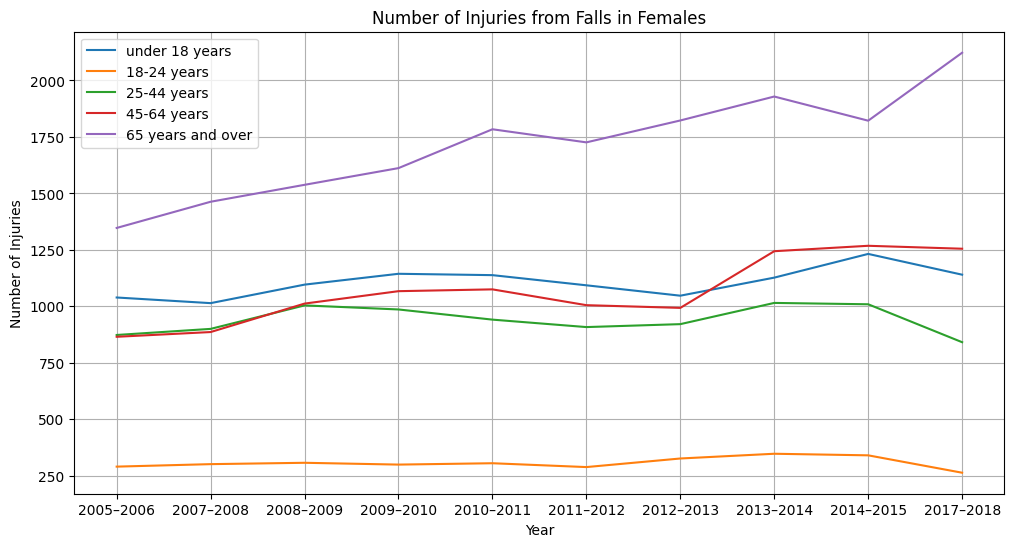

```python
# Make the 'year' column the x-axis, with the other columns on the y-axis
x_axis = females['year']
y_axis_columns = females.columns[1:]

plt.figure(figsize=(12, 6))

for column in y_axis_columns:
  plt.plot(x_axis, females[column], label=column)

plt.xlabel('Year')
plt.ylabel('Number of Injuries')
plt.title('Number of Injuries from Falls in Females')
plt.legend()
plt.grid(True)
plt.show()
```

From the graphic above, I can conclude that females ages 65 and over are far more frequently injured by falling as compared to the other age groups. It is also interesting to see that there is a trend of elderly females becoming increasingly injured by falling as time has progressed from 2005 to 2018. Looking at the graphic, most age groups tend to follow the same position and trend on the graph. However, females ages 18-24 years appear to have the least number of injuries caused by falling.

## Summary and Futher Directions

With this dataset, I am able to explore the relationships between age, sex, and injury mechanisms over time. Further transformations of this dataset requires the conversion of some variables into categorical values. For example, in the first 'data' DataFrame, there are many variables that I would like to melt into their own values, such as the following:

- Variable: unintentional injuries, values: falls, struck by or against objects or people, motor vehicle accidents, cut or pierce
- Variable: sex, values: both sexes, male, female
- Variable: age, values: all ages crude, under 18 years, 18-24 years, 25-44 years, 45-64 years, 65 years and over

With this conversion, I can efficiently categorize and use the 'groupby' function in my data table to both extract and organize data, rather than searching for specific columns (such as when creating my 'females' dataframe). Eventually, I would like to generate a model to predict the likelihood of an individual to be sent to the ER via injury based off of their age and sex.